# Project: Investigate a Dataset (FBI Gun Data!)

- Introduction
- Data Wrangling
- Exploratory Data Analysis
- Conclusions

## Introduction

> The FBI Gun Data Set is a set of data described by 2 files, a file which has the data of each state as percentiles of population,races,etc.

> The other file contains the gun data of each state as (HandGun,LongGun,Others) and each is distributed to (repawn,rechecked,redemption,rental,etc....)

## Questions

> 1- Is Gun Usage increasing or Decreasing over the time

> 2- What is the trend of Gun Types Usage

> 3- What Census data associated with higher gun usage?

> 4- Which states have had the highest growth in gun registrations?

```python
# Use this cell to set up import statements for all of the packages that you
#   plan to use.
import pandas as pd
import numpy as np
import matplotlib.pyplot as plt
%matplotlib inline
import seaborn as sns
sns.set_style('darkgrid')
```

## Data Wrangling

```python
# Load your data and print out a few lines. Perform operations to inspect data
#   types and look for instances of missing or possibly errant data.
df_1 = pd.read_excel('gun_data.xlsx',sheet_name=None)
df_2 = pd.read_csv('U.S. Census Data.csv')
df_1.head()
```

|  | month | state | permit | permit_recheck | handgun | long_gun | other | multiple | admin | prepawn_handgun | ... | returned_other | rentals_handgun | rentals_long_gun | private_sale_handgun | private_sale_long_gun | private_sale_other | return_to_seller_handgun | return_to_seller_long_gun | return_to_seller_other | totals |
| --- | --- | --- | --- | --- | --- | --- | --- | --- | --- | --- | --- | --- | --- | --- | --- | --- | --- | --- | --- | --- | --- |
| 0 | 2017-09 | Alabama | 16717.0 | 0.0 | 5734.0 | 6320.0 | 221.0 | 317 | 0.0 | 15.0 | ... | 0.0 | 0.0 | 0.0 | 9.0 | 16.0 | 3.0 | 0.0 | 0.0 | 3.0 | 32019 |
| 1 | 2017-09 | Alaska | 209.0 | 2.0 | 2320.0 | 2930.0 | 219.0 | 160 | 0.0 | 5.0 | ... | 0.0 | 0.0 | 0.0 | 17.0 | 24.0 | 1.0 | 0.0 | 0.0 | 0.0 | 6303 |
| 2 | 2017-09 | Arizona | 5069.0 | 382.0 | 11063.0 | 7946.0 | 920.0 | 631 | 0.0 | 13.0 | ... | 0.0 | 0.0 | 0.0 | 38.0 | 12.0 | 2.0 | 0.0 | 0.0 | 0.0 | 28394 |
| 3 | 2017-09 | Arkansas | 2935.0 | 632.0 | 4347.0 | 6063.0 | 165.0 | 366 | 51.0 | 12.0 | ... | 0.0 | 0.0 | 0.0 | 13.0 | 23.0 | 0.0 | 0.0 | 2.0 | 1.0 | 17747 |
| 4 | 2017-09 | California | 57839.0 | 0.0 | 37165.0 | 24581.0 | 2984.0 | 0 | 0.0 | 0.0 | ... | 0.0 | 0.0 | 0.0 | 0.0 | 0.0 | 0.0 | 0.0 | 0.0 | 0.0 | 123506 |

5 rows × 27 columns

## Data Cleaning Phase

```python
#Data Cleaning
#Phase 1, Filling the Missing values
#1-the first column that has missing values was permit, it's missing values logically needs to be put so i
#put it as the mean of the column
mean = df_1['permit'].mean()
df_1['permit'] = df_1['permit'].fillna(mean)
################################
#2-the next column is admin , it has values that cant be replaced with the mean so i discarded the missing value rows
df_1.dropna(subset=['admin'],inplace=True)
```

```python
#3- the next columns reads the zero reading as nulls , so i removed every Null and put 0 in it
df_1[['permit_recheck','handgun','long_gun','other']] = df_1[['permit_recheck','handgun','long_gun','other']].fillna(0)

df_1[['prepawn_long_gun','redemption_long_gun','returned_long_gun','rentals_long_gun','private_sale_long_gun','return_to_seller_long_gun']]=df_1[['prepawn_long_gun','redemption_long_gun','returned_long_gun','rentals_long_gun','private_sale_long_gun','return_to_seller_long_gun']].fillna(0)

df_1[['prepawn_handgun','redemption_handgun','returned_handgun','rentals_handgun','private_sale_handgun','return_to_seller_handgun']]= df_1[['prepawn_handgun','redemption_handgun','returned_handgun','rentals_handgun','private_sale_handgun','return_to_seller_handgun']].fillna(0)

df_1[['prepawn_other','redemption_other','returned_other','private_sale_other','return_to_seller_other']] = df_1[['prepawn_other','redemption_other','returned_other','private_sale_other','return_to_seller_other']].fillna(0)
#4- check for duplicates
sum(df_1.duplicated()) # No Duplicated rows as it gives Zero
```

```
0
```

```python
#Extracting the needed columns (total of each gun type,state,date,total of all guns)
df_1['hand_gun_total'] = df_1['handgun'] + df_1['prepawn_handgun'] + df_1['redemption_handgun'] + df_1['returned_handgun'] + df_1['rentals_handgun'] + df_1['private_sale_handgun'] + df_1['return_to_seller_handgun']

df_1['long_gun_total'] = df_1['long_gun'] + df_1['prepawn_long_gun'] + df_1['redemption_long_gun'] + df_1['returned_long_gun'] + df_1['rentals_long_gun'] + df_1['private_sale_long_gun'] + df_1['return_to_seller_long_gun']

df_1['other_total'] = df_1['other'] + df_1['prepawn_other'] + df_1['redemption_other'] + df_1['returned_other']  + df_1['private_sale_other'] + df_1['return_to_seller_other']

df_1 = df_1[['month','state','permit','permit_recheck','hand_gun_total','long_gun_total','other_total','totals']]

#Fixing the data types from float to integers as these numbers refers to number of guns (Int)
df_1[['permit','permit_recheck','hand_gun_total','long_gun_total','other_total','totals']]=df_1[['permit','permit_recheck','hand_gun_total','long_gun_total','other_total','totals']].astype(int)
#Checking our work till now
df_1.info()
df_1.head()
```

```
<class 'pandas.core.frame.DataFrame'>
Int64Index: 12462 entries, 0 to 12484
Data columns (total 8 columns):
month             12462 non-null object
state             12462 non-null object
permit            12462 non-null int64
permit_recheck    12462 non-null int64
hand_gun_total    12462 non-null int64
long_gun_total    12462 non-null int64
other_total       12462 non-null int64
totals            12462 non-null int64
dtypes: int64(6), object(2)
memory usage: 876.2+ KB
```

|  | month | state | permit | permit_recheck | hand_gun_total | long_gun_total | other_total | totals |
| --- | --- | --- | --- | --- | --- | --- | --- | --- |
| 0 | 2017-09 | Alabama | 16717 | 0 | 7136 | 7619 | 230 | 32019 |
| 1 | 2017-09 | Alaska | 209 | 2 | 2570 | 3140 | 222 | 6303 |
| 2 | 2017-09 | Arizona | 5069 | 382 | 12670 | 8717 | 925 | 28394 |
| 3 | 2017-09 | Arkansas | 2935 | 632 | 5668 | 7925 | 170 | 17747 |
| 4 | 2017-09 | California | 57839 | 0 | 37700 | 24978 | 2989 | 123506 |

```python
#Cleaning the data of the second dataset
#We will remove the Fact Note column
df_2.drop('Fact Note',axis = 1,inplace = True)
df_2 = df_2.set_index('Fact').T
df_2.head()
#Now we have the dataset of gun usage at every city at many dates , and another set describing Some properties of each city
```

| Fact | Population estimates, July 1, 2016, (V2016) | Population estimates base, April 1, 2010, (V2016) | Population, percent change - April 1, 2010 (estimates base) to July 1, 2016, (V2016) | Population, Census, April 1, 2010 | Persons under 5 years, percent, July 1, 2016, (V2016) | Persons under 5 years, percent, April 1, 2010 | Persons under 18 years, percent, July 1, 2016, (V2016) | Persons under 18 years, percent, April 1, 2010 | Persons 65 years and over, percent, July 1, 2016, (V2016) | Persons 65 years and over, percent, April 1, 2010 | ... | nan | Value Flags | - | D | F | FN | nan | S | X | Z |
| --- | --- | --- | --- | --- | --- | --- | --- | --- | --- | --- | --- | --- | --- | --- | --- | --- | --- | --- | --- | --- | --- |
| Alabama | 4,863,300 | 4,780,131 | 1.70% | 4,779,736 | 6.00% | 6.40% | 22.60% | 23.70% | 16.10% | 13.80% | ... | NaN | NaN | NaN | NaN | NaN | NaN | NaN | NaN | NaN | NaN |
| Alaska | 741,894 | 710,249 | 4.50% | 710,231 | 7.30% | 7.60% | 25.20% | 26.40% | 10.40% | 7.70% | ... | NaN | NaN | NaN | NaN | NaN | NaN | NaN | NaN | NaN | NaN |
| Arizona | 6,931,071 | 6,392,301 | 8.40% | 6,392,017 | 6.30% | 7.10% | 23.50% | 25.50% | 16.90% | 13.80% | ... | NaN | NaN | NaN | NaN | NaN | NaN | NaN | NaN | NaN | NaN |
| Arkansas | 2,988,248 | 2,916,025 | 2.50% | 2,915,918 | 6.40% | 6.80% | 23.60% | 24.40% | 16.30% | 14.40% | ... | NaN | NaN | NaN | NaN | NaN | NaN | NaN | NaN | NaN | NaN |
| California | 39,250,017 | 37,254,522 | 5.40% | 37,253,956 | 6.30% | 6.80% | 23.20% | 25.00% | 13.60% | 11.40% | ... | NaN | NaN | NaN | NaN | NaN | NaN | NaN | NaN | NaN | NaN |

5 rows × 85 columns

```python
#Fixing data types of columns we need
#First function is used to get a float percentage (float without % sign in range of 0-100)


def p2float(row):
    X = []
    if(row[-1] == "%"):
        X = float(row.rstrip('%'))
    elif(row == 'Z'):
        X = 0
    else:
        X = 100*float(row)
    return X
```

```python
#Second function is used to apply the first function in case we need float,or apply another line to extract ints from strings
def ConvertSeries(Dataframe,Series=None,percent=True):
    if(percent == True): #indicates we need to extract float from percentages
        for item in Dataframe.columns:
            Dataframe[item] = Dataframe.apply(lambda row:p2float(row[item]),axis=1)
    elif(Series != None):#if percent = False and There is a series given so we extract ints from this series
        for item in Dataframe.columns:
            Dataframe[item] = Series.str.extract('(\d+)').astype(int)
    else: #if percent = False and there is no series given then we are converting all the dataframe columns
        for item in Dataframe.columns:
            Dataframe[item] = Dataframe[item].str.extract('(\d+)').astype(int)
```

```python
#We want to change the census data from strings into floats and ints
df_Census_2016 = df_2[['Persons under 5 years, percent, July 1, 2016,  (V2016)','Persons under 18 years, percent, July 1, 2016,  (V2016)','Persons 65 years and over, percent,  July 1, 2016,  (V2016)'
                      ,'Female persons, percent,  July 1, 2016,  (V2016)','White alone, percent, July 1, 2016,  (V2016)','Black or African American alone, percent, July 1, 2016,  (V2016)',
                      'American Indian and Alaska Native alone, percent, July 1, 2016,  (V2016)', 'Asian alone, percent, July 1, 2016,  (V2016)','Native Hawaiian and Other Pacific Islander alone, percent, July 1, 2016,  (V2016)','Two or More Races, percent, July 1, 2016,  (V2016)',
                 'Hispanic or Latino, percent, July 1, 2016,  (V2016)','White alone, not Hispanic or Latino, percent, July 1, 2016,  (V2016)']]

df_Census_2010 = df_2[['Persons under 5 years, percent, April 1, 2010','Persons under 18 years, percent, April 1, 2010','Persons 65 years and over, percent, April 1, 2010',
                 'Female persons, percent, April 1, 2010']]

ConvertSeries(df_Census_2016)
ConvertSeries(df_Census_2010)

df_Census_2016.head()
```

| Fact | Persons under 5 years, percent, July 1, 2016, (V2016) | Persons under 18 years, percent, July 1, 2016, (V2016) | Persons 65 years and over, percent, July 1, 2016, (V2016) | Female persons, percent, July 1, 2016, (V2016) | White alone, percent, July 1, 2016, (V2016) | Black or African American alone, percent, July 1, 2016, (V2016) | American Indian and Alaska Native alone, percent, July 1, 2016, (V2016) | Asian alone, percent, July 1, 2016, (V2016) | Native Hawaiian and Other Pacific Islander alone, percent, July 1, 2016, (V2016) | Two or More Races, percent, July 1, 2016, (V2016) | Hispanic or Latino, percent, July 1, 2016, (V2016) | White alone, not Hispanic or Latino, percent, July 1, 2016, (V2016) |
| --- | --- | --- | --- | --- | --- | --- | --- | --- | --- | --- | --- | --- |
| Alabama | 6.0 | 22.6 | 16.1 | 51.6 | 69.3 | 26.8 | 0.7 | 1.4 | 0.1 | 1.6 | 4.2 | 65.8 |
| Alaska | 7.3 | 25.2 | 10.4 | 47.7 | 66.1 | 3.8 | 15.2 | 6.3 | 1.3 | 7.3 | 7.0 | 61.2 |
| Arizona | 6.3 | 23.5 | 16.9 | 50.3 | 83.3 | 4.9 | 5.4 | 3.4 | 0.3 | 2.8 | 30.9 | 55.5 |
| Arkansas | 6.4 | 23.6 | 16.3 | 50.9 | 79.4 | 15.7 | 1.0 | 1.6 | 0.3 | 2.0 | 7.3 | 72.9 |
| California | 6.3 | 23.2 | 13.6 | 50.3 | 72.7 | 6.5 | 1.7 | 14.8 | 0.5 | 3.8 | 38.9 | 37.7 |

```python
#Create a Date Column to refer to the year only, will be used in question 2
Year = []
for item in df_1['month']:
    Year.append(item.split("-")[0])
df_1['Year'] = Year

#Get the average total of each type within a year
HandGun_Average = []
LongGun_Average = []
Years = df_1['Year'].unique()
for item in Years:
    Year_Gun_List = df_1[df_1['Year']==item]
    HandGun_Average.append(Year_Gun_List['hand_gun_total'].mean())
    LongGun_Average.append(Year_Gun_List['long_gun_total'].mean())
```

## Research Question 1 (Is Gun Usage increasing or Decreasing over the time?)

>

```python
Dates = df_1['month'].unique()
Totals_Average = []
#This loop will iterate on each month , and average all the gun usage of all states together so we have a reading of
#Average gun used all over us in this month
for item in Dates:
    DataFrame = df_1[df_1['month']==item]
    Totals_Average.append(np.average(DataFrame['totals']))
#To make sure that the total number of months in dataset = total number of Average readings in the other
assert len(Totals_Average) == len(Dates)

Totals_Average = Totals_Average[::-1] #Reverse the list so we begin with the lowest Date instead of 2017
df_Totals = pd.DataFrame({'Totals':Totals_Average})
df_Totals.info()
df_Total_Final = pd.rolling_mean(df_Totals,6)
```

```
<class 'pandas.core.frame.DataFrame'>
RangeIndex: 227 entries, 0 to 226
Data columns (total 1 columns):
Totals    227 non-null float64
dtypes: float64(1)
memory usage: 1.9 KB
```

```
Text(0,0.5,'Total Gun Usage')
```

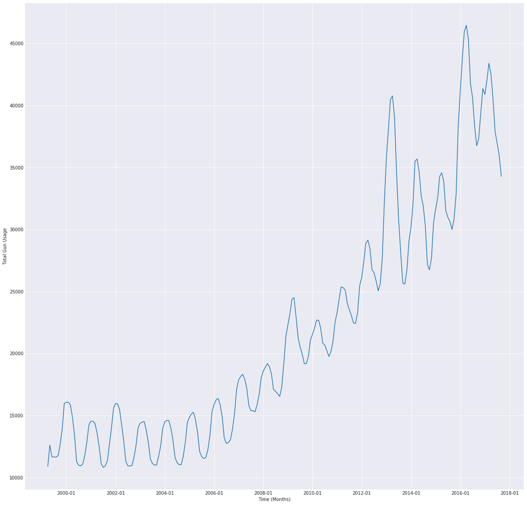

```python
import datetime as dt
import matplotlib.dates as mdates
x = [dt.datetime.strptime(d,'%Y-%m').date() for d in Dates] #This is for having the dates as x-axis labels
plt.figure(1,figsize=(20,20))
plt.gca().xaxis.set_major_formatter(mdates.DateFormatter('%Y-%m'))
plt.plot(x,df_Total_Final[::-1])
plt.xlabel('Time (Months)')
plt.ylabel('Total Gun Usage')
```

# Answer To Question 1

## Question ( Is Gun Usage increasing or decreasing over time ? )

## Answer:

> From the above visualization we see that the overall gun usage are increasing (With ups and downs during several times)

> The Maximum value of Gun Usage is near at the beggining of 2016

> From the study of the plot we can detect an increase that is considered as the highest peak in Gun Usage in the upcoming 2 years

### Research Question 2 (What is the trend of Gun Types Usage?)

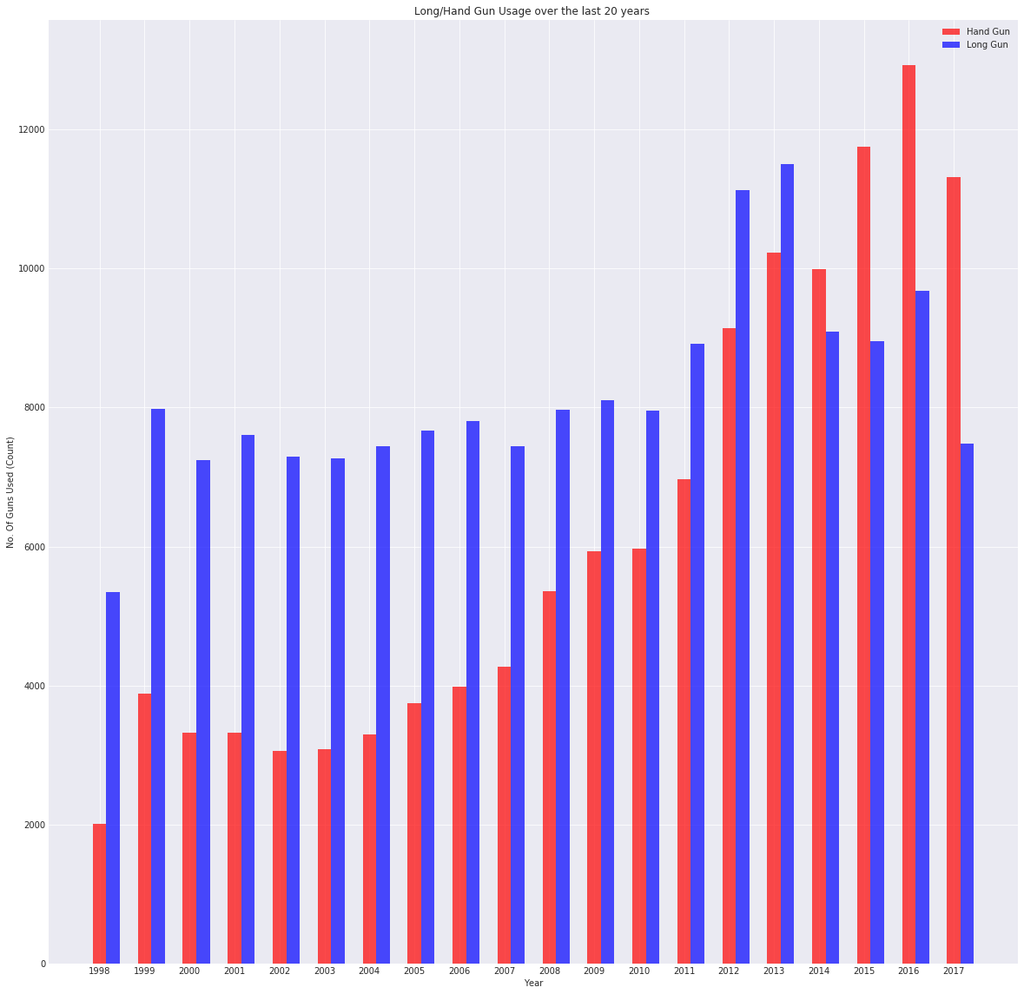

```python
#Let's plot a bar graph for each year registrations of hand guns and long guns
plt.figure(figsize=(20,20))
ind = np.arange(len(HandGun_Average))
width = 0.3
Hand_Plot = plt.bar(ind,HandGun_Average[::-1],width,color='r',alpha=.7,label = 'Hand Gun',tick_label = Years[::-1])
Long_Plot = plt.bar(ind+width,LongGun_Average[::-1],width,color ='b',alpha=.7,label = 'Long Gun')
plt.xlabel('Year')
plt.ylabel('No. Of Guns Used (Count)')
plt.title('Long/Hand Gun Usage over the last 20 years ')
plt.legend()
```

# Answer To Question 2 (What is the trend of Gun Types Usage?)

## Answer:

> Based on the above visualization , we can see that in the Period from 1998 to 2013 , Long Guns was Used more than the Hand Guns, But as we see , since 2013 till now , The usage of Hand guns are exceptionally elevated and became the trend of gun usage

## Research Question 3 (What census data are related to high gun usage?)

```python
#For question 3 we need to get every city's total gun usage average,and do a scatter plot between
#each Census property and the amount of guns used
#Since the States in Census data are not the same as gun data (There is 5 additional states in gun data),Then we will need a list
#of Census States to extract gun data for them only

States_Census = df_Census_2016.index.values #50 States
```

```python
def ExtractData(Period,Month=False):
    if( Month == False ):
        DataFrame = pd.DataFrame()
        DataFrame = df_1[df_1['Year'] == Period]
        GunList = []
        for item in States_Census:
            GunList.append(DataFrame[DataFrame['state']==item]['totals'].mean())
        return GunList
    else:
        DataFrame = pd.DataFrame()
        DataFrame = df_1[df_1['month'] == Period]
        GunList = []
        for item in States_Census:
            GunList.append(DataFrame[DataFrame['state']==item]['totals'].mean())
        return GunList
```

```python
##Then i will take the Data of guns at the dates 2016 July and 2010 April because that is when we have the population data

df_July_2016 =ExtractData('2016-07',Month=True)
df_April_2010 =ExtractData('2010-04',Month=True)
assert len(df_Census_2016['Persons under 5 years, percent, July 1, 2016,  (V2016)']) == len(df_April_2010)
#Now we have the data ready to explore
```

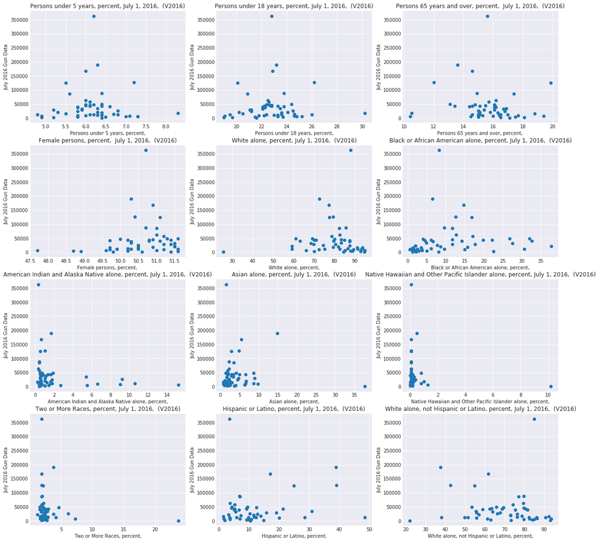

```python
def PlotScatter(rows,columns,x,y):
    i = 1
    plt.figure(figsize=(20,20))
    for item in x.columns:
        plt.subplot(rows,columns,i)
        plt.scatter(x[item],y)
        plt.title(item)

        if(y == df_July_2016):
            plt.xlabel(item[:-23])
            plt.ylabel('July 2016 Gun Data')
        elif(y== df_April_2010):
            plt.xlabel(item[:-23])
            plt.ylabel('April 2010 Gun Data')
        elif(y==df_Gun_2011_2015_Average):
            plt.xlabel(item)
            plt.ylabel('2011-2015 Gun Data')
        elif(y==Gun_2015):
            plt.xlabel(item)
            plt.ylabel('2015 Gun Data')
        elif(y==Gun_2012):
            plt.xlabel(item)
            plt.ylabel('2012 Gun Data')
        elif(y==Gun_2010):
            plt.xlabel(item)
            plt.ylabel('2010 Gun Data')
        i += 1

PlotScatter(4,3,df_Census_2016,df_July_2016)
```

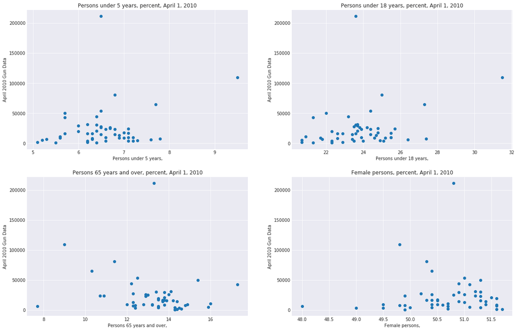

```python
PlotScatter(3,2,df_Census_2010,df_April_2010) #Used 3 here to make it more adjusted , 2x2 subplots make it elongated
```

## So we now have the plots which clearly states that the relation between the age percentages gun total usage are weak.